# Logistic_regression

VC

4/13/2020

Data that are not normally distributed. Specifically have non normal but still independent errors. The process of generalized linear model allows use of function F to fit the data on a linearized scale F(y) = F(f(x)) while calculating the variance on an untrasnformed scale in order to correct the distortion that linearization may induce (Bolker 2008)

In GLM ‘F’ is the link function

Link 1. Logit: When f is the logistic curve; F is the logit function; y = f(x); F(y) = log(y/(1-y)) =x, y = (exp(x)/1+exp(x)) Link 2. Log: y = exp(x) Link 3: Square root, y = x^2 Link 4: Inverse, y= 1/x Link 5: Probit, inverse of cumulative distribution function

In GLM, family of non-normal error (exponential) can be handled. It includes: 1. poisson- pick log link function 2. binomial- pick logit link function or log link or probit 3. gamma- inverse or log 4. normal- identity (linear regression)

```r
#install.packages("mlbench")
library(mlbench)
data("PimaIndiansDiabetes2", package = "mlbench")
pim<-PimaIndiansDiabetes2
head(pim)
```

|  | pregnant | glucose | pressure | triceps | insulin | mass | pedigree | age | diabetes |
| --- | --- | --- | --- | --- | --- | --- | --- | --- | --- |
| 1 | 6 | 148 | 72 | 35 | NA | 33.6 | 0.627 | 50 | pos |
| 2 | 1 | 85 | 66 | 29 | NA | 26.6 | 0.351 | 31 | neg |
| 3 | 8 | 183 | 64 | NA | NA | 23.3 | 0.672 | 32 | pos |
| 4 | 1 | 89 | 66 | 23 | 94 | 28.1 | 0.167 | 21 | neg |
| 5 | 0 | 137 | 40 | 35 | 168 | 43.1 | 2.288 | 33 | pos |
| 6 | 5 | 116 | 74 | NA | NA | 25.6 | 0.201 | 30 | neg |

## Data exploration

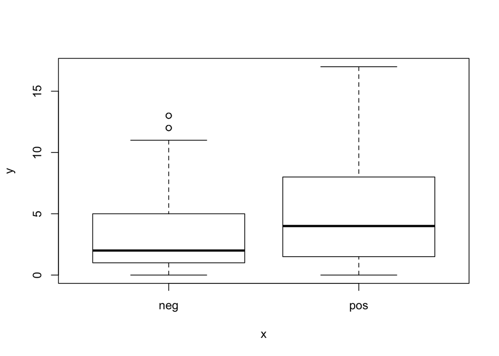

```r
library(ggplot2)
plot(pim$diabetes,pim$pregnant)
```

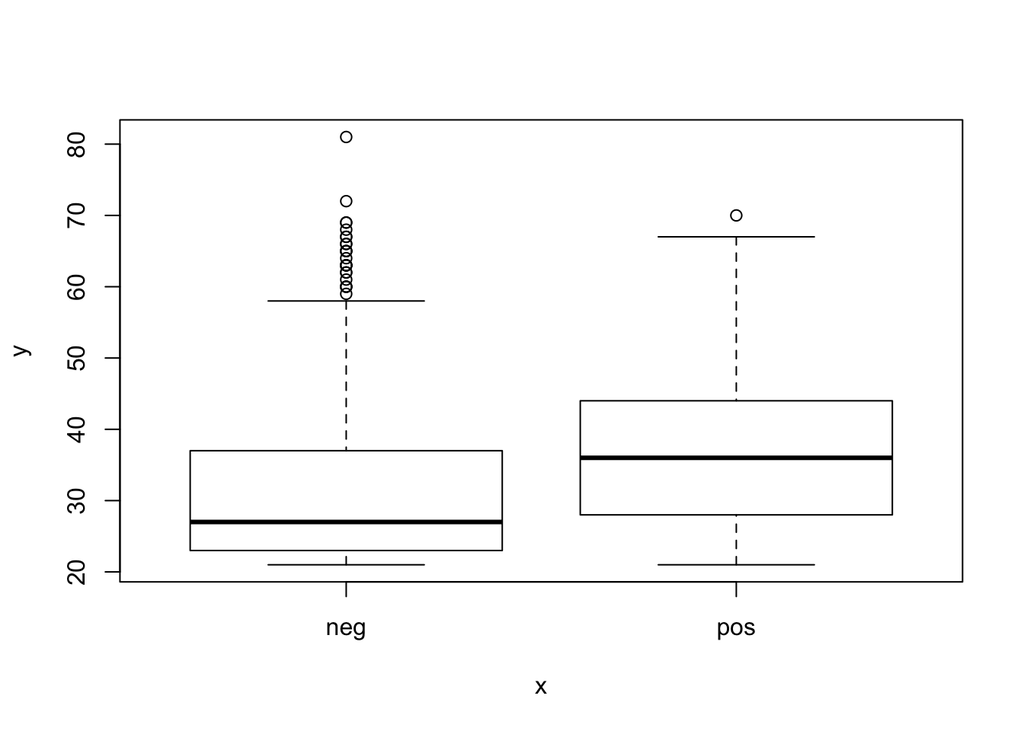

```r
plot(pim$diabetes,pim$age)
```

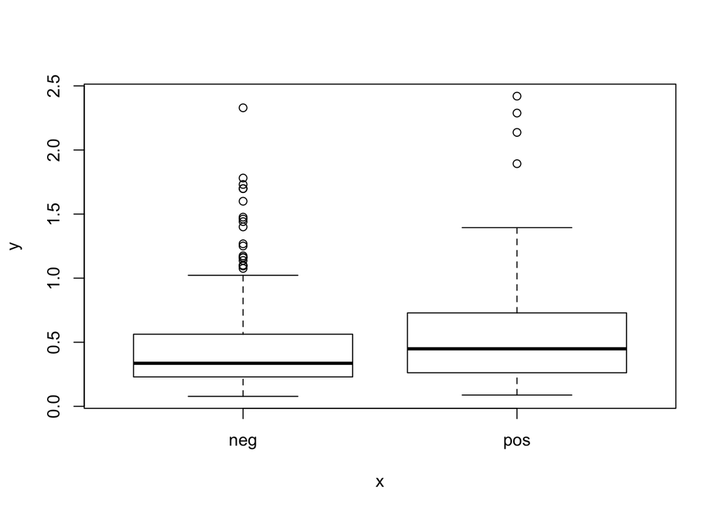

```r
plot(pim$diabetes,pim$pedigree)
```

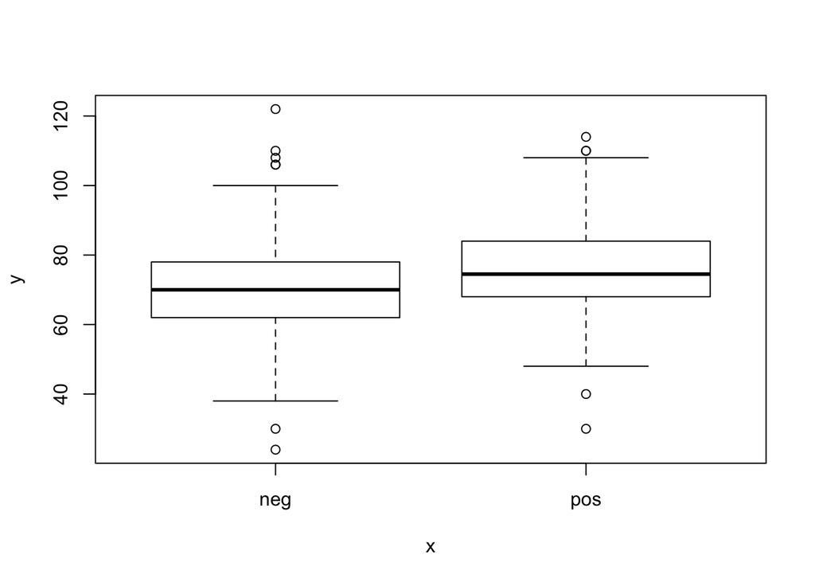

```r
plot(pim$diabetes,pim$pressure)
```

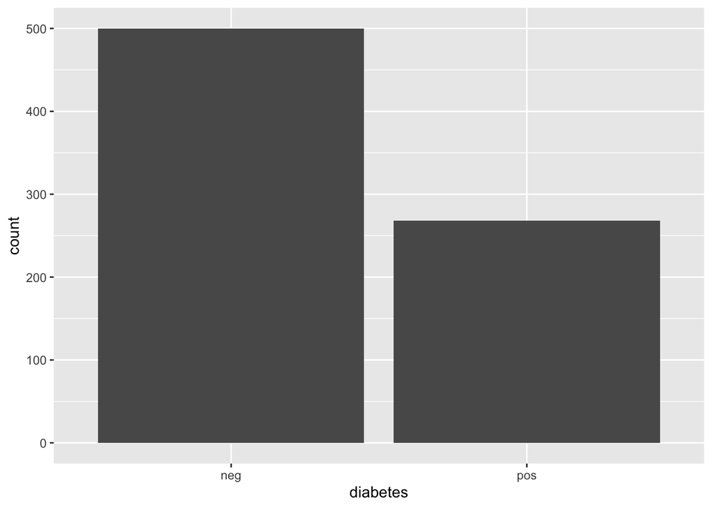

```r
ggplot(pim)+geom_histogram(aes(diabetes),stat = 'count')
```

## Fitting glm models

We will use glm of family binomial, with link function logit which assumes both 0 and 1 are equally distributed approximately In linear models, we estimate the parameters by minimizing the sum of the squared residuals. Equivalent to finding parameters that maximize the likelihood.

In a GLM we also fit parameters by maximizing the likelihood. The deviance is -2* maximum log likelihood + c. Estimation is equivalent to finding parameter values that minimize the deviance.

```r
m1<- glm(diabetes ~ age + pregnant, family = binomial(link="logit"), data= pim)

#m2<- glm(diabetes ~ age + pregnant, family = binomial(link="probit"), data= pim)
m2<- glm(diabetes ~ age * pregnant, family = 'binomial', data= pim)
m3<- glm(diabetes ~  age , family = 'binomial', data= pim)
m4<-glm(diabetes ~ pedigree, family = 'binomial', data= pim)
```

# Model selection

m2 is the best supported model

```r
bbmle::AICtab(m1,m2,m3,m4,base=T, logLik=T)
```

```
##    logLik AIC    dLogLik dAIC   df
## m2 -466.2  940.3   19.3     0.0 4
## m1 -470.5  947.1   14.9     6.8 3
## m3 -475.4  954.7   10.1    14.4 2
## m4 -485.4  974.9    0.0    34.5 2
```

```r
summary(m1)
```

```
##
## Call:
## glm(formula = diabetes ~ age + pregnant, family = binomial(link = "logit"),
##     data = pim)
##
## Deviance Residuals:
##     Min       1Q   Median       3Q      Max
## -1.7016  -0.8710  -0.7334   1.2170   1.7736
##
## Coefficients:
##              Estimate Std. Error z value Pr(>|z|)
## (Intercept) -1.962950   0.240726  -8.154 3.51e-16 ***
## age          0.029648   0.007639   3.881 0.000104 ***
## pregnant     0.082346   0.026658   3.089 0.002008 **
## ---
## Signif. codes:  0 '***' 0.001 '**' 0.01 '*' 0.05 '.' 0.1 ' ' 1
##
## (Dispersion parameter for binomial family taken to be 1)
##
##     Null deviance: 993.48  on 767  degrees of freedom
## Residual deviance: 941.10  on 765  degrees of freedom
## AIC: 947.1
##
## Number of Fisher Scoring iterations: 4
```

```r
summary(m2)
```

```
##
## Call:
## glm(formula = diabetes ~ age * pregnant, family = "binomial",
##     data = pim)
##
## Deviance Residuals:
##    Min      1Q  Median      3Q     Max
## -1.584  -0.924  -0.685   1.182   1.925
##
## Coefficients:
##               Estimate Std. Error z value Pr(>|z|)
## (Intercept)  -2.868931   0.398572  -7.198 6.11e-13 ***
## age           0.056526   0.012045   4.693 2.70e-06 ***
## pregnant      0.345314   0.093268   3.702 0.000214 ***
## age:pregnant -0.006803   0.002309  -2.946 0.003216 **
## ---
## Signif. codes:  0 '***' 0.001 '**' 0.01 '*' 0.05 '.' 0.1 ' ' 1
##
## (Dispersion parameter for binomial family taken to be 1)
##
##     Null deviance: 993.48  on 767  degrees of freedom
## Residual deviance: 932.33  on 764  degrees of freedom
## AIC: 940.33
##
## Number of Fisher Scoring iterations: 4
```

Intercept: related to predictions when the predictor has value 0.

Slope: determines how steeply the probability of diabetes moves from 0 to 1, as age and pregnancy and age*preganncy increases.

# Check variance inflation

If you are in doubt about a variable to be included based on p value, you can check values of VIF to see is they should be included VIF >10 suggests models have multicollinarity problem, its gives VIF for each variable.

```r
library(car)
vif(m1) #
```

```
##      age pregnant
## 1.352771 1.352771
```

```r
# Predict the probability (p) of diabete positivity
newdata= as.data.frame(expand.grid(age= seq(min(pim$age),40,1), pregnant=seq(min(pim$pregnant), max(pim$pregnant), 1)))
head(newdata)
```

|  | age | pregnant |
| --- | --- | --- |
| 1 | 21 | 0 |
| 2 | 22 | 0 |
| 3 | 23 | 0 |
| 4 | 24 | 0 |
| 5 | 25 | 0 |
| 6 | 26 | 0 |

```r
tail(newdata)
```

|  | age | pregnant |
| --- | --- | --- |
| 355 | 35 | 17 |
| 356 | 36 | 17 |
| 357 | 37 | 17 |
| 358 | 38 | 17 |
| 359 | 39 | 17 |
| 360 | 40 | 17 |

```r
newdata$probabilties<-  predict(m2,newdata =newdata, type = "response")
a<- predict(m2,newdata =newdata, type = "link")
head(a)
```

```
##         1         2         3         4         5         6
## -1.681883 -1.625357 -1.568831 -1.512305 -1.455778 -1.399252
```

```r
#exp(y)/(1+exp(y))
```

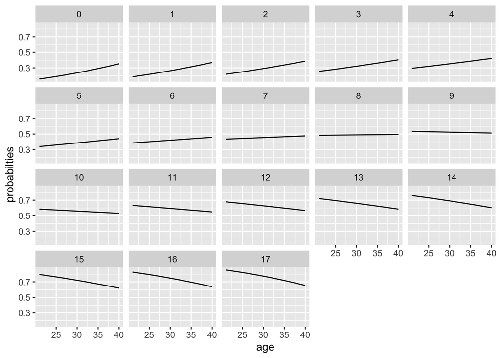

```r
library(ggplot2)
ggplot(newdata)+
  geom_line(aes( age,probabilties))+
  facet_wrap(~pregnant)
```

# Logistic regression diagnostics

If the model is correct and when sample size is large, the residual deviance D has a chi-square distribution approximately: residual D ∼ χ2dfResid

```r
# is the chi sq distrbution of deviance correct

pchisq(m1$deviance,m2$df.residual)
```

```
## [1] 0.9999887
```

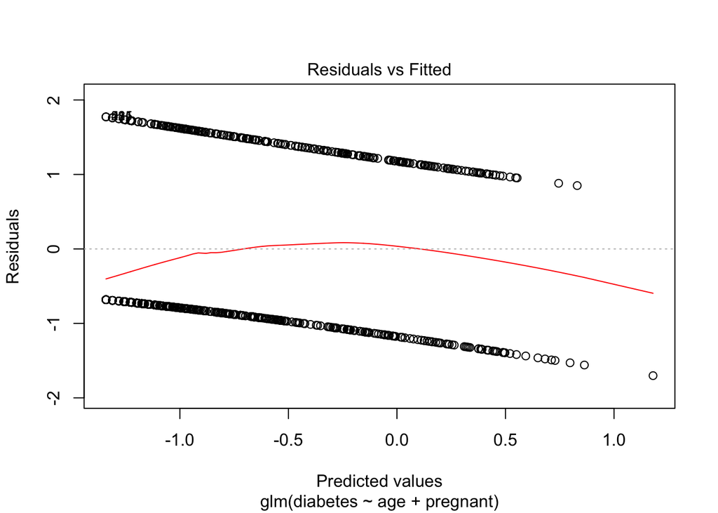

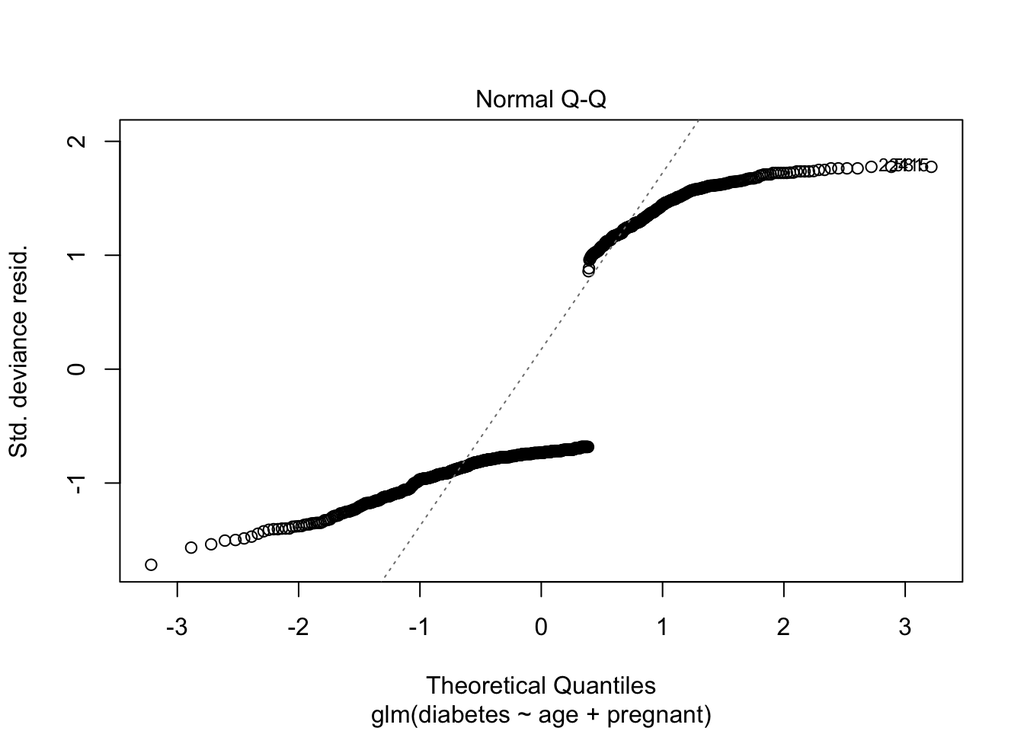

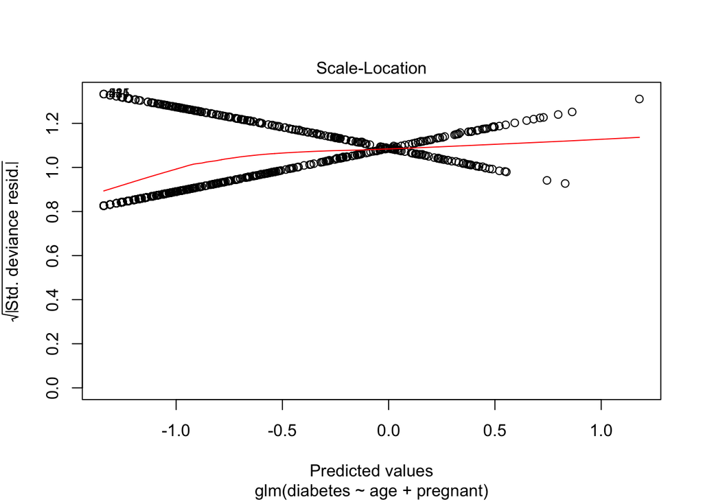

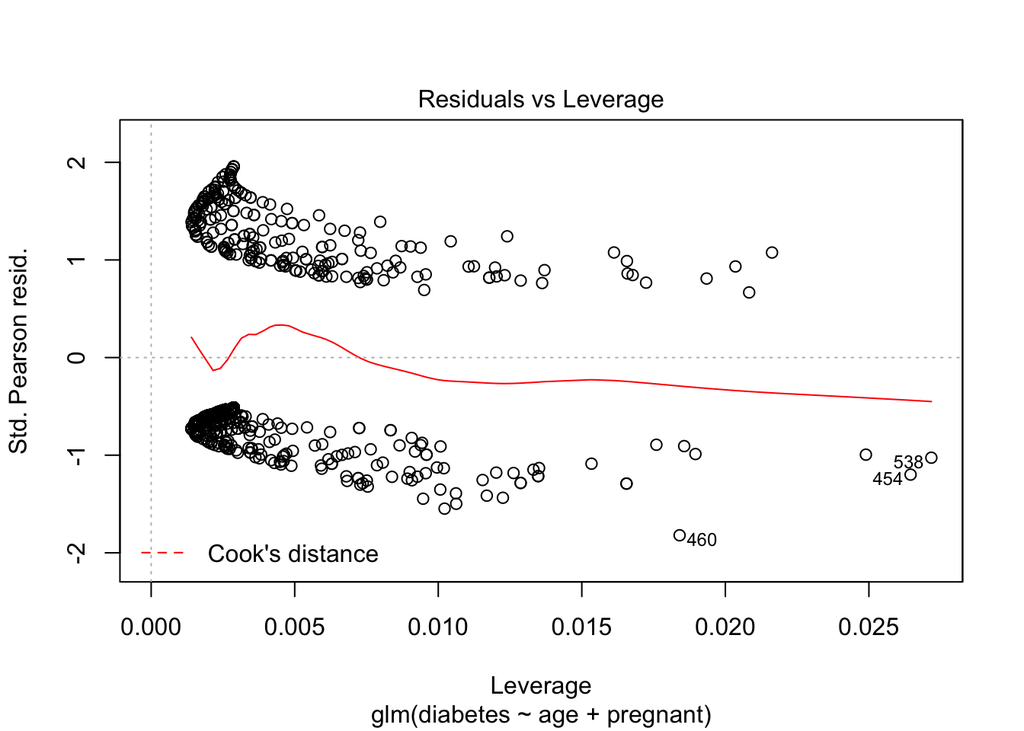

```r
plot(m1)
```

```r
#residual plots
```

```r
a.b<- DHARMa::simulateResiduals(m1)
```